# Example RNA-Seq Program for Paired-End RNA

Laura Saba

2022-02-24

The goal of this program is to provide a general frame work for a typical bulk RNA-Seq analysis.

## Project Folder Set-Up

It is easiest to follow along with this guide, if you set up a project folder that contains the following subfolders:

- raw_reads - should contain the original fastq files
- trimmed_reads
- aligned_reads
- data
- code
- quantitation

## Step 1 - Examine raw reads

For this example we are going to use six libraries available through SRA.

```
cd ~/Documents/IntroToRNASeq/raw_reads

# wild type samples
fastq-dump -I --split-files SRR12389348
fastq-dump -I --split-files SRR12389349
fastq-dump -I --split-files SRR12389350

# homozygous knockouts
fastq-dump -I --split-files SRR12389354
fastq-dump -I --split-files SRR12389355
fastq-dump -I --split-files SRR12389356
```

Most of the programs to follow can be used with zipped files, but for demonstration purposes, we use unzipped files in the remainder of the steps.

### Determine number of reads and length of reads sent for each sample

For this program, you want to make double check the header on the fastq file. For my example code, my fastq file entry looks like this.

```
@SRR12389348.1.1 1 length=101
NGCCGTCTTGCAGCGATACTGACTGAATGACTGGAACTGGTAGATGAANTCATCGATGATGNCCCAGAGCCACGGGTTGGGGAGCTCAAGGGGAGCAGGTC
+SRR12389348.1.1 1 length=101
#<<<<FBFBFFFFFFFBFFFFF/<FF</FFF/<FBBF<B<FFFF/<<B#<<<<<<FB/FFF#<<FBFFFFFFF//<FFFFB/B<//<BFFFF///<BB/7<
```

The header row starts with @SRR. In the program that counts reads, it looks for this header row to indicate a new read.

This is the code in countRawReads.sh

```
#!/bin/bash
FILES1=/projectFolder/raw_reads/*.fastq
for f in $FILES1
do
    awk '/@SRR/ {getline; print length($0)}' $f | awk -v sample="$f" '{sum+=$1} END {print sample,sum/NR,NR}' >> /projectFolder/data/rawReadCounts.txt
done
```

You will have to change ‘projectFolder’ to the pathway to the project folder that you set up initially. The ‘@SRR’ should be changed to the appropriate indicator for the header.

```
cd ~/Documents/IntroToRNASeq/code
./countRawReads.sh
```

The R code below reads in the txt file generated when counting reads per sample. Much of it will have to be changed to get the data to look ‘pretty’ for your particular samples.

```r
rm(list=ls())

library(knitr)

projectFolder <- "~/Documents/GitHub/IntroToRNASeq/"

rawCounts = read.table(file=paste0(projectFolder,"data/rawReadCounts.txt"),sep=" ",header=FALSE,fill=TRUE)

rawCounts$readFrag = as.numeric(rawCounts$V3)
rawCounts$file = unlist(lapply(strsplit(rawCounts$V1,split="/",fixed=TRUE),function(a) a[length(a)]))
rawCounts$sample = unlist(lapply(strsplit(rawCounts$file,split="_",fixed=TRUE),function(a) paste(a[1],collapse="_")))

readFragments = aggregate(rawCounts$readFrag,by=list(sample=rawCounts$sample),sum)
readFragments$numPairedReads = prettyNum(readFragments$x/2,big.mark=",",scientific=FALSE)
readFragments$numReadFragments = prettyNum(readFragments$x,big.mark=",",scientific=FALSE)

readFragments=readFragments[,colnames(readFragments)!="x"]
forPrint = readFragments[,c("sample","numPairedReads","numReadFragments")]
colnames(forPrint) = c("sample","Number of Paired-End Reads","Number of Read Fragments")
```

### Raw Reads/Read Fragments

```r
kable(forPrint,align=rep("c",ncol(readFragments)))
```

| sample | Number of Paired-End Reads | Number of Read Fragments |
| --- | --- | --- |
| SRR12389348 | 53,911,568 | 107,823,136 |
| SRR12389349 | 52,675,103 | 105,350,206 |
| SRR12389350 | 45,845,200 | 91,690,400 |
| SRR12389354 | 36,581,130 | 73,162,260 |
| SRR12389355 | 59,619,142 | 119,238,284 |
| SRR12389356 | 61,368,394 | 122,736,788 |

Total Number of Paired End Reads: 310,000,537  
Total Number of Read Fragments: 620,001,074  
Average Number of Paired End Reads Per Sample: 51,666,756

## Step 2 - Trim reads for adaptors and for quality

```
~/Documents/IntroToRNASeq/code/trimReads.sh
```

Here is what that program contains:

```
FILES1=/projectFolder/raw_reads/*_1*.fastq
for f in $FILES1
do
    f2=${f//_1/_2}
    f_trimmed=${f//.fastq/_trimmed.fastq}
    f_trimmed=${f_trimmed//raw_reads/trimmed_reads}
    f2_trimmed=${f2//.fastq/_trimmed.fastq}
    f2_trimmed=${f2_trimmed//raw_reads/trimmed_reads}
    cutadapt -q 20 -m 20 -a AGATCGGAAGAGCACACGTCTGAACTCCAGTCACCCGTCCCGATCTCGTATGCCGTCTTCTGCTTG -A AGATCGGAAGAGCGTCGTGTAGGGAAAGAGTGTAGATCTCGGTGGTCGCCGTATCATT -o $f_trimmed -p $f2_trimmed $f $f2
done
```

Again, you will have to put in the path to the raw data files.

### Characterize Trimmed Reads

The code for counting trimmed reads is very similar to the counting raw reads.

```
~/Documents/IntroToRNASeq/code/countTrimmedReads.sh &
```

Here is what the .sh file contains.

```
#!/bin/bash
FILES1=/projectFolder/trimmed_reads/*.fastq
for f in $FILES1
do
    awk '/@SRR/ {getline; print length($0)}' $f | awk -v sample="$f" '{sum+=$1} END {print sample,sum/NR,NR}' >> /projectFolder/data/trimmedReadCounts.txt
done
```

This R code just makes the txt file generated easier to read and adds the information on the raw reads.

```r
trimmed = read.table(file=paste0(projectFolder,"data/trimmedReadCounts.txt"),sep="",header=FALSE)
trimmed$file = unlist(lapply(strsplit(trimmed$V1,split="/",fixed=TRUE),function(a) a[length(a)]))
trimmed$sample = unlist(lapply(strsplit(trimmed$file,split="_",fixed=TRUE),function(a) paste(a[1],collapse="_")))
trimmed$read = unlist(lapply(strsplit(trimmed$file,split="_",fixed=TRUE),function(a) a[2]))

bySample = merge(trimmed[trimmed$read==1,c("sample","V2","V3")],trimmed[trimmed$read==2,c("sample","V2")],by="sample")
bySample$numReadFrag = bySample$V3*2
colnames(bySample) = c("sample","avgFragLength.R1","numReads","avgFragLength.R2","numReadFrag")

bySample = merge(readFragments,bySample,by=c("sample"))
bySample$pctReadsAfterTrim = paste(sprintf("%.1f",round(100*bySample$numReads/as.numeric(gsub(",","",bySample$numPairedReads)),1)),"%",sep="")

forPrint2 = bySample[,c("sample","numPairedReads","numReadFragments","avgFragLength.R1","avgFragLength.R2","numReadFrag","pctReadsAfterTrim")]
forPrint2$avgFragLength.R1 = sprintf("%.1f",round(forPrint2$avgFragLength.R1,1))
forPrint2$avgFragLength.R2 = sprintf("%.1f",round(forPrint2$avgFragLength.R2,1))
forPrint2$numReadFrag = prettyNum(forPrint2$numReadFrag,big.mark=",")

colnames(forPrint2) = c("sample","Number of Paired-End Reads","Number of Read Fragments","Average Read Fragment Length After Trimming (first read fragment)","Average Read Fragment Length After Trimming (second read fragment)","Number of Read Fragments After Trimming","Percent of Read Fragments That Remained After Trimming")
```

### Trimmed Reads/Read Fragments

```r
kable(forPrint2,align=rep("c",ncol(forPrint2)))
```

| sample | Number of Paired-End Reads | Number of Read Fragments | Average Read Fragment Length After Trimming (first read fragment) | Average Read Fragment Length After Trimming (second read fragment) | Number of Read Fragments After Trimming | Percent of Read Fragments That Remained After Trimming |
| --- | --- | --- | --- | --- | --- | --- |
| SRR12389348 | 53,911,568 | 107,823,136 | 99.9 | 99.8 | 107,346,862 | 99.6% |
| SRR12389349 | 52,675,103 | 105,350,206 | 98.7 | 98.5 | 104,789,224 | 99.5% |
| SRR12389350 | 45,845,200 | 91,690,400 | 99.7 | 99.6 | 91,275,080 | 99.5% |
| SRR12389354 | 36,581,130 | 73,162,260 | 99.5 | 99.4 | 72,595,822 | 99.2% |
| SRR12389355 | 59,619,142 | 119,238,284 | 99.7 | 99.5 | 118,596,234 | 99.5% |
| SRR12389356 | 61,368,394 | 122,736,788 | 99.5 | 99.4 | 121,871,622 | 99.3% |

Total Number of Paired End Reads After Trimming: 308,237,422  
Total Number of Read Fragments After Trimming: 616,474,844  
Average Number of Paired End Reads Per Sample After Trimming: 51,372,904

## Step 3 - Align trimmed reads to genome

First, you need to download the most recent version of the genome from Ensembl, e.g., ftp://ftp.ensembl.org/pub/pub/release-105/fasta/rattus_norvegicus/dna/Rattus_norvegicus.mRatBN7.2.dna.toplevel.fa.gz

Second, build the HISAT2 index for genome.

```
hisat2-build ~/Documents/IntroToRNASeq/index/Rattus_norvegicus.mRatBN7.2.dna.toplevel.fa ~/Documents/IntroToRNASeq/index/rn7_hisat2
```

Third, align trimmed reads to genome.

```
hisat2 --rna-strandness RF --dta -p 8 -x ~/Documents/IntroToRNASeq/index/rn7_hisat2 -1 ~/Documents/IntroToRNASeq/trimmed_reads/SRR12389348_1_trimmed.fastq -2 ~/Documents/IntroToRNASeq/trimmed_reads/SRR12389348_2_trimmed.fastq | samtools view -bS - > ~/Documents/IntroToRNASeq/aligned_reads/WT1.bam
```

## Step 4 - Transcriptome Reconstruction

### Prepare reads for transcriptome assembly

If you want to merge samples within a group prior to transcriptome assembly with StringTie, BAM files need to be sorted and then merged.

Below is some example code:

```
cd ~/Documents/IntroToRNASeq/aligned_reads/

## sort each file separately
samtools sort SRR12389348.bam -o SRR12389348.sorted
samtools sort SRR12389349.bam -o SRR12389349.sorted
samtools sort SRR12389350.bam -o SRR12389350.sorted

## merge three files into one bam
samtools merge WT.bam SRR12389348.sorted.bam SRR12389349.sorted.bam SRR12389350.sorted.bam
```

### De novo transcriptome assembly with StringTie

Download the GTF file of Ensembl transcripts to ‘guide’ the assembly. http://ftp.ensembl.org/pub/release-105/gtf/rattus_norvegicus/Rattus_norvegicus.mRatBN7.2.105.gtf.gz

Create group-specific transcriptome assembly:

```
stringtie /data/hi-seq/LRAP.KO/alignedReads/HISAT2/KO.naive.bam -p 8 -o /data/home/sabal/lncRNA.KO/RNA-Seq/reconstruction/lncKO_KO_Recon.gtf -G ~/Documents/index/Rattus_norvegicus.Rnor_6.0.87.gtf
```

Repeat this step for all groups.

Merge the group-specific transcriptomes:

```
stringtie --merge -p 8 -o lncKO_merged_Recon.gtf mergeList.txt
```

Compare the reconstructed transcriptome to the Ensembl transcriptome

```
gffcompare -r ~/Documents/index/Rattus_norvegicus.Rnor_6.0.87.gtf -G -o /data/home/sabal/lncRNA.KO/RNA-Seq/reconstruction/lncKO_merged_wEnsembl /data/home/sabal/lncRNA.KO/RNA-Seq/reconstruction/lncKO_KO_Recon.gtf
```

## Step 5 - Quantitate Merged De Novo Transcriptome Assembly

Prepare RSEM reference using new GTF file and genome sequence

```
rsem-prepare-reference --gtf /data/home/sabal/lncRNA.KO/RNA-Seq/reconstruction/lncKO_merged_Recon.gtf --bowtie2 ~/Documents/index/BNLx.rn6.spikes.fa /data/home/sabal/lncRNA.KO/RNA-Seq/reconstruction/lncKO_merged_Recon.hisat
```

Prepare RSEM reference using Ensembl GTF file and genome sequence

```
rsem-prepare-reference --gtf ~/Documents/IntroToRNASeq/index/Rattus_norvegicus.mRatBN7.2.105.gtf --bowtie2 ~/Documents/IntroToRNASeq/index/Rattus_norvegicus.mRatBN7.2.dna.toplevel.fa ~/Documents/IntroToRNASeq/index/ensembl_rsem
```

Run RSEM for each sample (starting with trimmed reads), e.g.:

```
rsem-calculate-expression -p 8 --time --seed 978 --bowtie2 --forward-prob=0.0 --no-bam-output --seed-length 20 --paired-end ~/Documents/IntroToRNASeq/trimmedReads/WT_5_CGGCTATG_L003_R1_001_trimmed.fastq ~/Documents/IntroToRNASeq/trimmedReads/WT_5_CGGCTATG_L003_R2_001_trimmed.fastq /data/home/sabal/lncRNA.KO/RNA-Seq/reconstruction/lncKO_merged_Recon.hisat ~/Documents/IntroToRNASeq/quantitation/RSEM.koRecon/WT5
```

## Step 6 - Differential Expression Analysis

Read in gtf file

```r
rm(list=ls())

library(dplyr)
bf = "/Volumes/sabal/lncRNA.KO/RNA-Seq/"

gtf = read.table(file=paste(bf,"reconstruction/lncKO_merged_wEnsembl.annotated.gtf",sep=""),sep="\t",header=FALSE)

transcripts = gtf %>% filter(V3=="transcript")

extractVars = function(data,column,var) unlist(lapply(strsplit(data[,column],split=";",fixed=TRUE), function(a) gsub(paste(var," ",sep=""),"",a[grep(var,a)])))

transcripts$transcript_id = extractVars(transcripts,"V9","transcript_id")
transcripts$gene_id = extractVars(transcripts,"V9","gene_id")
transcripts$class_code = extractVars(transcripts,"V9","class_code")
transcripts$gene_name[grep("gene_name",transcripts$V9)] = extractVars(transcripts,"V9","gene_name")
transcripts$ensembl[grep("cmp_ref",transcripts$V9)] = extractVars(transcripts,"V9","cmp_ref")

anno = transcripts %>% select(V1,V4,V5,V7,transcript_id,gene_id,class_code,gene_name,ensembl)
colnames(anno)[1:4] = c("chr","start","end","strand")

#write.table(anno,file="~/Documents/GitHub/IntroToRNASeq/data/annotationForDeNovoTranscriptAssembly.txt",sep="\t",row.names=FALSE,col.names=TRUE)
```

Class codes are at http://cole-trapnell-lab.github.io/cufflinks/cuffcompare/index.html

Read in RSEM data

```r
samples = c("WT1","WT2","WT3","Het1","Het2","Het3","KO1","KO2","KO3")

for(i in samples){
  x = read.table(file=paste(bf,"quantitation/RSEM.koRecon/",i,".naive.isoforms.results",sep=""),sep="\t",header=TRUE)
  x = x[,c("transcript_id","gene_id","expected_count")]
  colnames(x)[3] = i
  if(i!=samples[1]) cnts = merge(x,cnts,by=c("transcript_id","gene_id"))
  if(i==samples[1]) cnts = x
}


for(i in samples){
  x = read.table(file=paste(bf,"quantitation/RSEM.koRecon/",i,".naive.isoforms.results",sep=""),sep="\t",header=TRUE)
  x = x[,c("transcript_id","gene_id","TPM")]
  colnames(x)[3] = i
  if(i!=samples[1]) tpm = merge(x,tpm,by=c("transcript_id","gene_id"))
  if(i==samples[1]) tpm = x
}

#write.table(cnts,file="~/Documents/GitHub/IntroToRNASeq/data/isoformCnts.txt",sep="\t",row.names=FALSE,col.names=TRUE)
#write.table(tpm,file="~/Documents/GitHub/IntroToRNASeq/data/isoformTPM.txt",sep="\t",row.names=FALSE,col.names=TRUE)
```

Filter Transcripts Based on Read Counts

```r
rm(list=ls())

library(RUVSeq)
library(limma)
library(DESeq2)

cnts <- read.table(file="~/Documents/GitHub/IntroToRNASeq/data/isoformCnts.txt",sep="\t",header=TRUE)
anno <- read.table(file="~/Documents/GitHub/IntroToRNASeq/data/annotationForDeNovoTranscriptAssembly.txt",sep="\t",header=TRUE)
spikes = anno$transcript_id[grep("ERCC",anno$chr)]

rownames(cnts) = cnts$transcript_id

filtered = cnts[!(rownames(cnts) %in% spikes),-c(1:2)]  #remove control genes
filtered = filtered[rowSums(filtered)>50,]  # more than 50 total reads across all samples

counts = round(filtered)
```

Examine relationships between samples

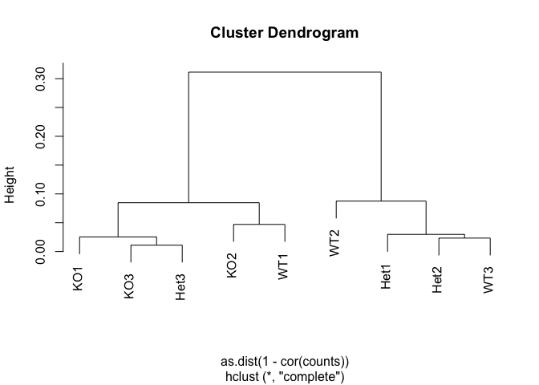

```r
plot(hclust(as.dist(1-cor(counts))))
```

Apply RUV using empirically derived negative controls

Relative Log Expression - Prior to RUV

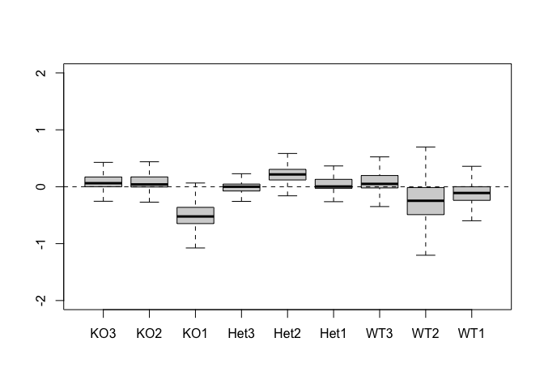

```r
plotRLE(seqExpressionSet, outline=FALSE, ylim=c(-2, 2))
```

Relative Log Expression - After RUV

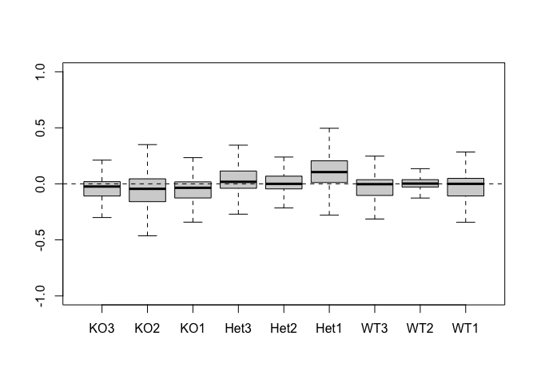

```r
plotRLE(ruvgSet, outline=FALSE, ylim=c(-1, 1))
```

Clustering of Samples After RUV

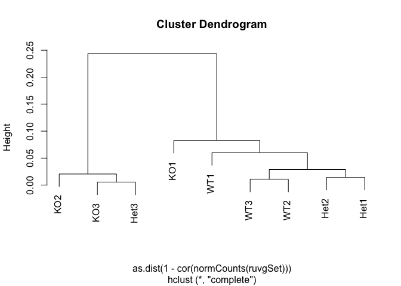

```r
plot(hclust(as.dist(1-cor(normCounts(ruvgSet)))))
```

Differential Expression Analysis

Merge differential expression results with annotation

Summary of significant transcripts: Number of transcripts: 150 Number of genes: 140